# Assignment 1 - Notebook

Luomeng Tan

14 Feb 2022

# Clean the data and map to HUGO symbols

## 1 - Download the data

First, I downloaded the data in GSE178521 (Hu et al., 2022). This data set have 6 samples, 3 replicates for the control (GFPkd1, GFPkd2, GFPkd3) and 3 replicates for the test condition (PRMT5kd1, PRMT5kd2, PRMT5kd3).

```r
library(knitr)

if (!requireNamespace("BiocManager", quietly = TRUE))
  install.packages("BiocManager")

if (!requireNamespace("GEOquery", quietly = TRUE))
  BiocManager::install("GEOquery")
library(GEOquery)
# Download the supplementary file
if(!dir.exists('GSE178521')) {
  sfiles = getGEOSuppFiles('GSE178521', fetch_files = TRUE)
  (fnames <- rownames(sfiles))
} else {
  sfiles = getGEOSuppFiles('GSE178521', fetch_files = FALSE)
  (fnames <- paste(getwd(), 'GSE178521', sfiles$fname, sep = "/"))
}
```

```
## [1] "/home/rstudio/projects/GSE178521/GSE178521_gene_count_matrix.txt.gz"
## [2] "/home/rstudio/projects/GSE178521/GSE178521_genes_fpkm_expression.txt.gz"
```

```r
# we want to use the first file, which is the gene count matrix.
raw_count <- read.delim(fnames[1], header = TRUE)
```

## 2 - Assess

Let’s briefly take a look at the count matrix. We have 58,825 rows (genes) in this data, and none of the gene_ids occur more than once. There are only about 20,000 - 25,000 genes in humans, but I got a lot more rows in my starting data. Based on my research, there might be some pseudo genes and non-coding genes. I am not sure whether or not that is the case here, but I will filter this data first.

```r
# we have 58825 genes
dim(raw_count)
```

```
## [1] 58825     7
```

```r
kable(raw_count[1:15, ], format = "pipe")
```

| gene_id | GFPkd1 | GFPkd2 | GFPkd3 | PRMT5kd1 | PRMT5kd2 | PRMT5kd3 |
| --- | --- | --- | --- | --- | --- | --- |
| ENSG00000282222 | 0 | 0 | 0 | 0 | 0 | 0 |
| ENSG00000282221 | 0 | 0 | 0 | 0 | 0 | 0 |
| ENSG00000212040 | 0 | 0 | 0 | 0 | 0 | 0 |
| ENSG00000110514 | 6020 | 6299 | 5418 | 5120 | 6625 | 5485 |
| ENSG00000086015 | 4124 | 4315 | 3674 | 3316 | 4242 | 3387 |
| ENSG00000211769 | 0 | 0 | 0 | 0 | 0 | 0 |
| ENSG00000211768 | 0 | 0 | 0 | 0 | 0 | 0 |
| ENSG00000250337 | 365 | 442 | 459 | 382 | 359 | 482 |
| ENSG00000255071 | 0 | 0 | 0 | 0 | 0 | 0 |
| ENSG00000211767 | 0 | 0 | 0 | 0 | 0 | 0 |
| ENSG00000211766 | 0 | 0 | 0 | 0 | 0 | 0 |
| ENSG00000211765 | 0 | 0 | 0 | 0 | 0 | 0 |
| ENSG00000211764 | 0 | 0 | 0 | 0 | 0 | 0 |
| ENSG00000201510 | 0 | 0 | 0 | 0 | 0 | 0 |
| ENSG00000169740 | 1220 | 1086 | 1086 | 1030 | 1333 | 968 |

```r
# check duplicates
any(table(raw_count$gene_id) > 1)
```

```
## [1] FALSE
```

```r
if (!requireNamespace("edgeR", quietly = TRUE))
  BiocManager::install("edgeR")

library(edgeR)
cpms <- cpm(raw_count[,2:7])
# get rid of low counts
keep <- rowSums(cpms >1) >= 3
count_filtered = raw_count[keep,]
# we have 15159 genes left
dim(count_filtered)
```

```
## [1] 15159     7
```

```r
kable(count_filtered[1:5, ], format = "pipe")
```

|  | gene_id | GFPkd1 | GFPkd2 | GFPkd3 | PRMT5kd1 | PRMT5kd2 | PRMT5kd3 |
| --- | --- | --- | --- | --- | --- | --- | --- |
| 4 | ENSG00000110514 | 6020 | 6299 | 5418 | 5120 | 6625 | 5485 |
| 5 | ENSG00000086015 | 4124 | 4315 | 3674 | 3316 | 4242 | 3387 |
| 8 | ENSG00000250337 | 365 | 442 | 459 | 382 | 359 | 482 |
| 15 | ENSG00000169740 | 1220 | 1086 | 1086 | 1030 | 1333 | 968 |
| 17 | ENSG00000261609 | 1213 | 1154 | 1062 | 888 | 1085 | 1285 |

## 3 - Map

Since this dataset only contains the gene IDs, I mapped the gene IDs to the HGNC symbols using biomaRt.

```r
if (!requireNamespace("biomaRt", quietly = TRUE))
  BiocManager::install("biomaRt")

library(biomaRt)

ensembl <- useMart("ensembl")
ensembl <- useDataset("hsapiens_gene_ensembl", mart = ensembl)

#check to see if PRMT5_id_conversion file exists
conversion_stash <- "PRMT5_id_conversion.rds"
if(file.exists(conversion_stash)){
  PRMT5_id_conversion <- readRDS(conversion_stash)
} else {
  PRMT5_id_conversion <- getBM(attributes = c("ensembl_gene_id","hgnc_symbol"),
                            filters = c("ensembl_gene_id"),
                            values = count_filtered$gene_id,
                            mart = ensembl)
  saveRDS(PRMT5_id_conversion, conversion_stash)
}
```

```
## Batch submitting query [=======>-----------------------] 25% eta: 1m Batch
## submitting query [===============>---------------] 50% eta: 29s Batch submitting
## query [======================>--------] 75% eta: 11s
```

We don’t have all of the genes mapped to HGNC symbols. I also noticed that many of the genes don’t get a meaningful HGNC symbols, with the symbol to be an empty string. I searched some of those gene IDs and found that those genes code for novel proteins.

```r
# number of genes that aren't mapped
nrow(count_filtered) - length(which(count_filtered$gene_id %in%
                                      PRMT5_id_conversion$ensembl_gene_id))
```

```
## [1] 34
```

```r
# number of genes with HGNC symbols to be ''
length(PRMT5_id_conversion$ensembl_gene_id[
  which(PRMT5_id_conversion$hgnc_symbol == '')])
```

```
## [1] 951
```

```r
# added HGNC symbols to our data frame using merge
count_filtered_annot <- merge(PRMT5_id_conversion, count_filtered,
                                 by.x = 1, by.y = 1, all.y = TRUE)

kable(count_filtered_annot[1:5,1:5], type = "pipe")
```

| ensembl_gene_id | hgnc_symbol | GFPkd1 | GFPkd2 | GFPkd3 |
| --- | --- | --- | --- | --- |
| ENSG00000000003 | TSPAN6 | 825 | 837 | 698 |
| ENSG00000000419 | DPM1 | 4295 | 4061 | 3058 |
| ENSG00000000457 | SCYL3 | 826 | 1069 | 865 |
| ENSG00000000460 | C1orf112 | 2405 | 2193 | 1867 |
| ENSG00000000971 | CFH | 4572 | 5337 | 4883 |

```r
# We can check the number of genes aren't mapped or with HGNC symbols to be ''
# in the merged data frame
ensembl_id_missing_gene_index <- which(is.na(count_filtered_annot$hgnc_symbol) |
                                         count_filtered_annot$hgnc_symbol == '')

length(ensembl_id_missing_gene_index)
```

```
## [1] 985
```

```r
kable(count_filtered_annot[ensembl_id_missing_gene_index[1:10], 1:5], type = "pipe")
```

|  | ensembl_gene_id | hgnc_symbol | GFPkd1 | GFPkd2 | GFPkd3 |
| --- | --- | --- | --- | --- | --- |
| 1596 | ENSG00000093100 |  | 772 | 434 | 292 |
| 2835 | ENSG00000108958 |  | 317 | 295 | 182 |
| 3091 | ENSG00000111788 |  | 719 | 821 | 749 |
| 3628 | ENSG00000116883 | NA | 92 | 68 | 75 |
| 4277 | ENSG00000124593 |  | 5777 | 5616 | 2766 |
| 4766 | ENSG00000130489 | NA | 26 | 128 | 33 |
| 4804 | ENSG00000130723 | NA | 15855 | 18960 | 16676 |
| 4869 | ENSG00000131152 |  | 137 | 70 | 42 |
| 5059 | ENSG00000132832 |  | 88 | 67 | 66 |
| 6518 | ENSG00000144785 |  | 474 | 44 | 123 |

For those genes without a proper HGNC symbols, I used their gene IDs as their HGNC symbols.

```r
count_filtered_annot$hgnc_symbol[ensembl_id_missing_gene_index] <-
  count_filtered_annot$ensembl_gene_id[ensembl_id_missing_gene_index]

kable(count_filtered_annot[ensembl_id_missing_gene_index[1:10], 1:5], type = "pipe")
```

|  | ensembl_gene_id | hgnc_symbol | GFPkd1 | GFPkd2 | GFPkd3 |
| --- | --- | --- | --- | --- | --- |
| 1596 | ENSG00000093100 | ENSG00000093100 | 772 | 434 | 292 |
| 2835 | ENSG00000108958 | ENSG00000108958 | 317 | 295 | 182 |
| 3091 | ENSG00000111788 | ENSG00000111788 | 719 | 821 | 749 |
| 3628 | ENSG00000116883 | ENSG00000116883 | 92 | 68 | 75 |
| 4277 | ENSG00000124593 | ENSG00000124593 | 5777 | 5616 | 2766 |
| 4766 | ENSG00000130489 | ENSG00000130489 | 26 | 128 | 33 |
| 4804 | ENSG00000130723 | ENSG00000130723 | 15855 | 18960 | 16676 |
| 4869 | ENSG00000131152 | ENSG00000131152 | 137 | 70 | 42 |
| 5059 | ENSG00000132832 | ENSG00000132832 | 88 | 67 | 66 |
| 6518 | ENSG00000144785 | ENSG00000144785 | 474 | 44 | 123 |

## 4 - Clean

I chose not to remove any outliers since I think the data entries looks reasonable to me. Even though in the later section there are some entries to be negative infinity after cpm and log2 operation, I am not sure whether or not those rows should be removed, so I chose not to remove them here. In the previous step, I have removed the rows with low counts.

# Normalization

I normalized the data using Trimmed Mean of M-values (TMM) normalization method in the edgeR (Robinson et al., 2010) package. TMM and Relative Log Expression (RLE) give similar results. I chose TMM since I am used to work with edgeR.

```r
# Create an edgeR container for count data
filtered_data_matrix <- as.matrix(count_filtered_annot[,3:8])
rownames(filtered_data_matrix) <- count_filtered_annot$hgnc_symbol
d <- DGEList(counts = filtered_data_matrix,
             group = c('GFP', 'GFP', 'GFP', 'PRMT5', 'PRMT5', 'PRMT5'))

# Calculate the normalization factors
d <- calcNormFactors(d)
normalized_counts <- cpm(d)
```

I plotted two box plots showing the samples before and after normalization. Before normalization, we saw that the replicates don’t variate a lot. The plots look very similar before and after normalization, but we can still see slight difference if we look carefully.

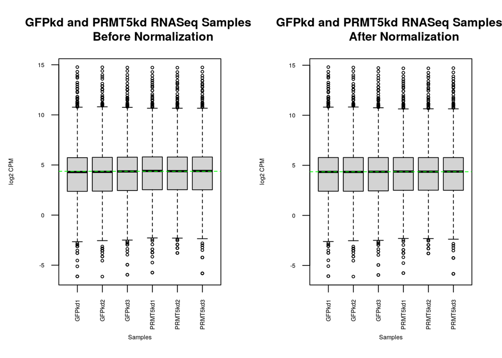

```r
par(mfrow=c(1,2))

# plot the box plot BEFORE normalization
data2plot_pre_norm <- log2(cpm(count_filtered_annot[ , 3:8]))
boxplot(data2plot_pre_norm, xlab = "Samples", ylab = "log2 CPM",
        las = 2, cex = 0.5, cex.lab = 0.5, cex.main = 1,
        cex.axis = 0.5, main = "GFPkd and PRMT5kd RNASeq Samples
        Before Normalization")
#draw the median on each box plot
abline(h = median(apply(data2plot_pre_norm, 2, median)),
       col = "green", lwd = 1, lty = "dashed")

# plot the box plot AFTER normalization
data2plot_post_norm <- log2(normalized_counts)
boxplot(data2plot_post_norm, xlab = "Samples", ylab = "log2 CPM",
        las = 2, cex = 0.5, cex.lab = 0.5, cex.main = 1,
        cex.axis = 0.5, main = "GFPkd and PRMT5kd RNASeq Samples
        After Normalization")
#draw the median on each box plot
abline(h = median(apply(data2plot_post_norm, 2, median)),
       col = "green", lwd = 1, lty = "dashed")
```

I also plotted the density plots for samples before and after normalization, and we also see very similar graphs before and after.

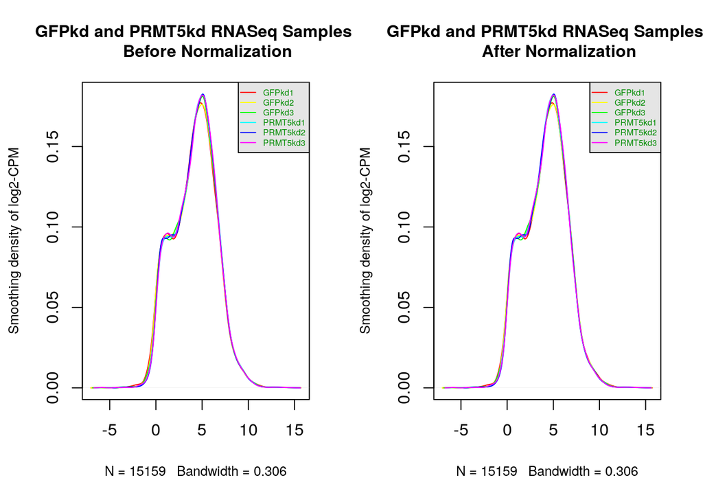

```r
par(mfrow=c(1,2))

# Plot the density plot BEFORE normalization
counts_density_pre_norm <- apply(data2plot_pre_norm, 2, density)

xlim <- 0; ylim <- 0
for (i in 1:length(counts_density_pre_norm)) {
  xlim <- range(c(xlim, counts_density_pre_norm[[i]]$x));
  ylim <- range(c(ylim, counts_density_pre_norm[[i]]$y))
}

cols <- rainbow(length(counts_density_pre_norm))
ltys <- rep(1, length(counts_density_pre_norm))

# plot the first density plot to initialize the plot
plot(counts_density_pre_norm[[1]], xlim = xlim, ylim = ylim, type = "n",
     ylab = "Smoothing density of log2-CPM",
     main = "GFPkd and PRMT5kd RNASeq Samples
     Before Normalization",
     cex.lab = 0.8, cex.main = 1)

# plot each line
for (i in 1:length(counts_density_pre_norm)) {
  lines(counts_density_pre_norm[[i]], col = cols[[i]])
}

# create legend
legend("topright", colnames(data2plot_pre_norm),
       col = cols, lty = ltys, cex = 0.5,
       border = "blue",  text.col = "green4",
       merge = TRUE, bg = "gray90")

# Plot the density plot AFTER normalization
counts_density_post_norm <- apply(data2plot_post_norm, 2, density)

xlim <- 0; ylim <- 0
for (i in 1:length(counts_density_post_norm)) {
  xlim <- range(c(xlim, counts_density_post_norm[[i]]$x));
  ylim <- range(c(ylim, counts_density_post_norm[[i]]$y))
}

cols <- rainbow(length(counts_density_post_norm))
ltys <- rep(1, length(counts_density_post_norm))

# plot the first density plot to initialize the plot
plot(counts_density_post_norm[[1]], xlim = xlim, ylim = ylim, type = "n",
     ylab = "Smoothing density of log2-CPM",
     main = "GFPkd and PRMT5kd RNASeq Samples
     After Normalization",
     cex.lab = 0.8, cex.main = 1)
# plot each line
for (i in 1:length(counts_density_post_norm)) {
  lines(counts_density_post_norm[[i]], col = cols[[i]])
}

#create legend
legend("topright", colnames(data2plot_post_norm),
       col = cols, lty = ltys, cex = 0.5,
       border = "blue",  text.col = "green4",
       merge = TRUE, bg = "gray90")
```

# Final result

The final result after the normalization is the normalized_counts I have before.

```r
finalized_normalized_counts <- normalized_counts

kable(finalized_normalized_counts[1:10, ], type = "pipe")
```

|  | GFPkd1 | GFPkd2 | GFPkd3 | PRMT5kd1 | PRMT5kd2 | PRMT5kd3 |
| --- | --- | --- | --- | --- | --- | --- |
| TSPAN6 | 12.26959 | 12.08576 | 11.25919 | 10.67533 | 11.21711 | 10.29283 |
| DPM1 | 63.87621 | 58.63830 | 49.32750 | 48.21355 | 44.36641 | 45.74980 |
| SCYL3 | 12.28446 | 15.43569 | 13.95301 | 15.65471 | 17.90148 | 15.09848 |
| C1orf112 | 35.76770 | 31.66555 | 30.11591 | 29.87623 | 27.29689 | 25.88061 |
| CFH | 67.99581 | 77.06294 | 78.76592 | 69.25186 | 70.98913 | 85.61049 |
| FUCA2 | 116.09259 | 108.56965 | 108.22048 | 93.94661 | 100.40895 | 96.27029 |
| GCLC | 93.18936 | 91.14132 | 84.37939 | 73.90050 | 79.33742 | 83.28630 |
| NFYA | 31.48450 | 35.95404 | 36.14877 | 36.72976 | 37.42385 | 35.91132 |
| STPG1 | 12.28446 | 11.08944 | 13.35617 | 16.62853 | 15.72117 | 15.06353 |
| NIPAL3 | 43.59049 | 43.28924 | 45.14967 | 55.65505 | 47.88073 | 50.41565 |

# Summary: Interpret, and document

1. What are the control and test conditions of the dataset?
- The purpose of this RNA-seq experiment is to identify the whether inhibition of PRMT5 expression would affect the expression of certain genes related to tumorigenesis. So the test condition here is the knockdown of PRMT5 and the control is the knockdown of GFP.
2. Why is the dataset of interest to you?
- First, this dataset is an RNA-seq dataset with several replicates. Second, it is associated with human cancers, specifically lung cancer. I am very interested in cancer biology, so I think this dataset is very suitable for me.
3. Were there expression values that were not unique for specific genes? How did you handle these?
- No. There was no duplicate rows for specific genes.
4. Were there expression values that could not be mapped to current HUGO symbols?
- Yes, there are 34 expression values that could not be mapped to current HUGO symbols. Also, 951 values were mapped to an empty string. In total, 985 values aren’t preoperly mapped, which is about 6%.
5. How many outliers were removed?
- None.
6. How did you handle replicates?
- In this dataset, there are 3 biological replicates for each condition. From the box and density plots before normalization, I don’t think there are any outlier. The replicates didn’t variate a lot.
7. What is the final coverage of your dataset?
- I got 15159 genes left after cleaning. So the final coverage of the data is around 61% - 76%.

# Refernce

Hu, R., Zhou, B., Chen, Z., Chen, S., Chen, N., Shen, L., Xiao, H., & Zheng, Y. (2022). PRMT5 Inhibition Promotes PD-L1 Expression and Immuno-Resistance in Lung Cancer. Frontiers in immunology, 12, 722188. https://doi.org/10.3389/fimmu.2021.722188

Robinson, M. D., McCarthy, D. J., & Smyth, G. K. (2010). edgeR: a Bioconductor package for differential expression analysis of digital gene expression data. Bioinformatics (Oxford, England), 26(1), 139–140. https://doi.org/10.1093/bioinformatics/btp616